# Report 1: EPSS Lab

| **Course** | Cybersecurity Lab Course |
| --- | --- |
| **Student Name** | Lucas Lorenzo Jakin |
| **Student ID** | IN2300003 |
| **Date** | December 11, 2025 |

## Objective

The primary objective of this laboratory report is to analyze and interpret vulnerability data using the **Exploit Prediction Scoring System (EPSS)**. Unlike traditional scoring mechanisms that focus solely on the severity of a vulnerability, EPSS provides a probability-based score estimating the likelihood of a vulnerability being exploited in the wild within the next 30 days.

```python
import pandas as pd
import os
import re
import requests
import json
from collections import Counter
from matplotlib.patches import Patch
import streamlit as st
```

```python
import seaborn as sns
import matplotlib.pyplot as plt
sns.set_theme(style="whitegrid")
```

```python
from preprocessing_utils import preprocess_NVD_data
```

```python
data_path = 'data'
if not os.path.exists(data_path):
    os.makedirs(data_path)
```

# EPSS data

Download the EPSS data from https://www.first.org/epss/data_stats into `data` folder

### *TODO*:

- in the following cell, replace `epss_scores-2025-09-30.csv.gz` with the correct updated file (`epss_scores-2025-10-01.csv.gz`)

```python
epss_current = pd.read_csv(os.path.join(data_path, 'epss_scores-2025-10-01.csv.gz'), compression='gzip', header=1)
epss_current # a Python statement with a variable name at the end of a cell will display its contents below
```

|  | cve | epss | percentile |
| --- | --- | --- | --- |
| 0 | CVE-1999-0001 | 0.01141 | 0.77780 |
| 1 | CVE-1999-0002 | 0.10742 | 0.93087 |
| 2 | CVE-1999-0003 | 0.90362 | 0.99589 |
| 3 | CVE-1999-0004 | 0.03215 | 0.86596 |
| 4 | CVE-1999-0005 | 0.25334 | 0.96035 |
| ... | ... | ... | ... |
| 296328 | CVE-2025-9994 | 0.00060 | 0.19138 |
| 296329 | CVE-2025-9996 | 0.00179 | 0.40027 |
| 296330 | CVE-2025-9997 | 0.00182 | 0.40386 |
| 296331 | CVE-2025-9998 | 0.00023 | 0.04753 |
| 296332 | CVE-2025-9999 | 0.00040 | 0.11642 |

296333 rows × 3 columns

# NVD data

```python
base_url = "https://services.nvd.nist.gov/rest/json/cves/2.0"
date_start_NVD = '2025-09-01T00:00:00.000Z' # Do NOT change these dates
date_end_NVD   = '2025-10-01T00:00:00.000Z' # Do NOT change these dates
start_index = 0
results_per_page = 1000
total_results = 1

all_cves = []

while start_index < total_results:
    params = {
        "pubStartDate": date_start_NVD,
        "pubEndDate": date_end_NVD,
        "resultsPerPage": results_per_page,
        "startIndex": start_index,
        "noRejected": ""
    }
    response = requests.get(base_url, params=params, timeout=6)
    if response.status_code != 200:
        print("Error:", response.status_code)
        break

    data = response.json()
    total_results = data.get("totalResults", 0)

    all_cves.extend(data.get("vulnerabilities", []))

    start_index += results_per_page
    print(start_index)
```

```
1000
2000
3000
4000
5000
```

```python
# normalize and preprocess data
df = pd.json_normalize(all_cves, record_path=None, sep='.', max_level=None)
df = preprocess_NVD_data(df)

# remove vulnerabilities marked as "reject" or "reserved"
df = df[(df['cve.vulnStatus']!='Reserved') & (df['cve.vulnStatus']!='Reject')]

# merge NVD and EPSS data
df = df.merge(epss_current, left_on="cve.id", right_on="cve", how="left")
```

```python
# save nvd data
with open(os.path.join(data_path, "nvd_cves.json"), "w", encoding="utf-8") as f:
    json.dump(all_cves, f, indent=2)

# save the final dataframe
df.to_csv(os.path.join(data_path, "vuln_2025_09.csv"))
```

# Exploratory Data Analysis

- display some examples (e.g., the first two CVE records)

```python
df.head(10).T
# T for transpose
```

|  | 0 | 1 | 2 | 3 | 4 | 5 | 6 | 7 | 8 | 9 |
| --- | --- | --- | --- | --- | --- | --- | --- | --- | --- | --- |
| cve.id | CVE-2025-9751 | CVE-2025-9752 | CVE-2025-9753 | CVE-2025-9754 | CVE-2025-9755 | CVE-2025-9756 | CVE-2025-9567 | CVE-2025-9568 | CVE-2025-9569 | CVE-2025-9757 |
| cve.sourceIdentifier | cna@vuldb.com | cna@vuldb.com | cna@vuldb.com | cna@vuldb.com | cna@vuldb.com | cna@vuldb.com | twcert@cert.org.tw | twcert@cert.org.tw | twcert@cert.org.tw | cna@vuldb.com |
| cve.published | 2025-09-01 00:15:34.580000 | 2025-09-01 01:15:46.817000 | 2025-09-01 01:15:47.060000 | 2025-09-01 02:15:45.223000 | 2025-09-01 02:15:45.493000 | 2025-09-01 02:15:45.713000 | 2025-09-01 03:15:32.337000 | 2025-09-01 03:15:32.570000 | 2025-09-01 03:15:32.767000 | 2025-09-01 03:15:32.967000 |
| cve.lastModified | 2025-09-08 14:06:05.217000 | 2025-09-04 18:47:25.440000 | 2025-09-04 18:46:50.757000 | 2025-09-04 18:46:58.453000 | 2025-09-05 19:54:52.480000 | 2025-09-08 14:02:39.200000 | 2025-09-25 14:18:08.317000 | 2025-09-25 14:18:31.453000 | 2025-09-25 14:18:03.243000 | 2025-09-08 13:54:13.633000 |
| cve.vulnStatus | Analyzed | Analyzed | Analyzed | Analyzed | Analyzed | Analyzed | Analyzed | Analyzed | Analyzed | Analyzed |
| cve.references | [{'url': 'https://github.com/HAO-RAY/HCR-CVE/i... | [{'url': 'https://github.com/i-Corner/cve/issu... | [{'url': 'https://github.com/Yashh-G/zero-day-... | [{'url': 'https://github.com/Yashh-G/zero-day-... | [{'url': 'https://gist.github.com/0xSebin/147e... | [{'url': 'https://github.com/CSentinel/CVE/iss... | [{'url': 'https://www.twcert.org.tw/en/cp-139-... | [{'url': 'https://www.twcert.org.tw/en/cp-139-... | [{'url': 'https://www.twcert.org.tw/en/cp-139-... | [{'url': 'https://github.com/lrjbsyh/CVE_Hunte... |
| cve.cisaExploitAdd | NaN | NaN | NaN | NaN | NaN | NaN | NaN | NaN | NaN | NaN |
| cve.cisaActionDue | NaN | NaN | NaN | NaN | NaN | NaN | NaN | NaN | NaN | NaN |
| cve.cisaRequiredAction | NaN | NaN | NaN | NaN | NaN | NaN | NaN | NaN | NaN | NaN |
| cve.cisaVulnerabilityName | NaN | NaN | NaN | NaN | NaN | NaN | NaN | NaN | NaN | NaN |
| description | A weakness has been identified in Campcodes On... | A security vulnerability has been detected in ... | A vulnerability was detected in Campcodes Onli... | A flaw has been found in Campcodes Online Hosp... | A vulnerability has been found in Khanakag-17 ... | A vulnerability was found in PHPGurukul User M... | The eHRD developed by Sunnet has a Reflected C... | The eHRD developed by Sunnet has a Reflected C... | The eHRD developed by Sunnet has a Reflected C... | A vulnerability was determined in Campcodes/So... |
| vulnerable_cpes | [cpe:2.3:a:campcodes:online_learning_managemen... | [cpe:2.3:o:dlink:dir-852_firmware:1.00cn_b09:*... | [cpe:2.3:a:campcodes:online_hospital_managemen... | [cpe:2.3:a:campcodes:online_hospital_managemen... | [cpe:2.3:a:khanakag-17:library_management_syst... | [cpe:2.3:a:phpgurukul:user_management_system:1... | [cpe:2.3:a:sun.net:ehrd_ctms:-:*:*:*:*:*:*:*] | [cpe:2.3:a:sun.net:ehrd_ctms:-:*:*:*:*:*:*:*] | [cpe:2.3:a:sun.net:ehrd_ctms:-:*:*:*:*:*:*:*] | [cpe:2.3:a:campcodes:courier_management_system... |
| num_references | 6 | 6 | 5 | 5 | 5 | 6 | 2 | 2 | 2 | 6 |
| cwe_list | [CWE-74, CWE-89, CWE-89] | [CWE-77, CWE-78, CWE-78] | [CWE-79, CWE-94] | [CWE-79, CWE-94] | [CWE-79, CWE-94, CWE-79] | [CWE-74, CWE-89, CWE-89] | [CWE-79] | [CWE-79] | [CWE-79] | [CWE-74, CWE-89, CWE-89] |
| cvss_version | 3.1 | 3.1 | 3.1 | 3.1 | 3.1 | 3.1 | 3.1 | 3.1 | 3.1 | 3.1 |
| cvss_vectorString | CVSS:3.1/AV:N/AC:L/PR:N/UI:N/S:U/C:H/I:H/A:H | CVSS:3.1/AV:N/AC:L/PR:N/UI:N/S:U/C:H/I:H/A:H | CVSS:3.1/AV:N/AC:L/PR:H/UI:R/S:C/C:L/I:L/A:N | CVSS:3.1/AV:N/AC:L/PR:L/UI:R/S:C/C:L/I:L/A:N | CVSS:3.1/AV:N/AC:L/PR:N/UI:R/S:C/C:L/I:L/A:N | CVSS:3.1/AV:N/AC:L/PR:L/UI:N/S:U/C:H/I:H/A:H | CVSS:3.1/AV:N/AC:L/PR:N/UI:R/S:C/C:L/I:L/A:N | CVSS:3.1/AV:N/AC:L/PR:N/UI:R/S:C/C:L/I:L/A:N | CVSS:3.1/AV:N/AC:L/PR:N/UI:R/S:C/C:L/I:L/A:N | CVSS:3.1/AV:N/AC:L/PR:N/UI:N/S:U/C:H/I:H/A:H |
| cvss_baseScore | 9.8 | 9.8 | 4.8 | 5.4 | 6.1 | 8.8 | 6.1 | 6.1 | 6.1 | 9.8 |
| cvss_baseSeverity | CRITICAL | CRITICAL | MEDIUM | MEDIUM | MEDIUM | HIGH | MEDIUM | MEDIUM | MEDIUM | CRITICAL |
| cvss_attackVector | NETWORK | NETWORK | NETWORK | NETWORK | NETWORK | NETWORK | NETWORK | NETWORK | NETWORK | NETWORK |
| cvss_attackComplexity | LOW | LOW | LOW | LOW | LOW | LOW | LOW | LOW | LOW | LOW |
| cvss_privilegesRequired | NONE | NONE | HIGH | LOW | NONE | LOW | NONE | NONE | NONE | NONE |
| cvss_userInteraction | NONE | NONE | REQUIRED | REQUIRED | REQUIRED | NONE | REQUIRED | REQUIRED | REQUIRED | NONE |
| cvss_scope | UNCHANGED | UNCHANGED | CHANGED | CHANGED | CHANGED | UNCHANGED | CHANGED | CHANGED | CHANGED | UNCHANGED |
| cvss_confidentialityImpact | HIGH | HIGH | LOW | LOW | LOW | HIGH | LOW | LOW | LOW | HIGH |
| cvss_integrityImpact | HIGH | HIGH | LOW | LOW | LOW | HIGH | LOW | LOW | LOW | HIGH |
| cvss_availabilityImpact | HIGH | HIGH | NONE | NONE | NONE | HIGH | NONE | NONE | NONE | HIGH |
| cve | CVE-2025-9751 | CVE-2025-9752 | CVE-2025-9753 | CVE-2025-9754 | CVE-2025-9755 | CVE-2025-9756 | CVE-2025-9567 | CVE-2025-9568 | CVE-2025-9569 | CVE-2025-9757 |
| epss | 0.0003 | 0.00242 | 0.00026 | 0.00028 | 0.00028 | 0.00028 | 0.00047 | 0.00047 | 0.00047 | 0.0003 |
| percentile | 0.07395 | 0.47575 | 0.05727 | 0.06386 | 0.06393 | 0.06611 | 0.14213 | 0.14213 | 0.14213 | 0.07395 |

- show a bar plot with the daily volume of published CVEs

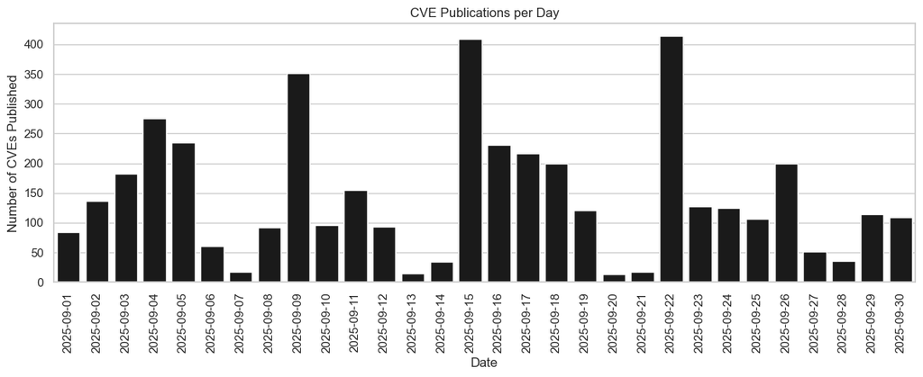

```python
published_counts = df["cve.published"].dt.date.value_counts().sort_index()

plt.figure(figsize=(12, 5))
sns.barplot(x=published_counts.index, y=published_counts.values, color="k" )
plt.xticks(rotation=90)
plt.xlabel("Date")
plt.ylabel("Number of CVEs Published")
plt.title("CVE Publications per Day")
plt.tight_layout()
plt.show()
```

```python
df.info()
```

```
<class 'pandas.core.frame.DataFrame'>
RangeIndex: 4322 entries, 0 to 4321
Data columns (total 29 columns):
 #   Column                      Non-Null Count  Dtype
---  ------                      --------------  -----
 0   cve.id                      4322 non-null   object
 1   cve.sourceIdentifier        4322 non-null   object
 2   cve.published               4322 non-null   datetime64[ns]
 3   cve.lastModified            4322 non-null   datetime64[ns]
 4   cve.vulnStatus              4322 non-null   object
 5   cve.references              4322 non-null   object
 6   cve.cisaExploitAdd          14 non-null     object
 7   cve.cisaActionDue           14 non-null     object
 8   cve.cisaRequiredAction      14 non-null     object
 9   cve.cisaVulnerabilityName   14 non-null     object
```

[output cut: 21 more lines]

- print the description of the last ten published vulnerabilities

```python
for idx, x in enumerate(df.sort_values('cve.published', ascending=False)[:10].iterrows()):
    print('-'*100)
    print(x[1]['cve.id'], x[1]['cve.published'])
    print(x[1].description)
```

```
----------------------------------------------------------------------------------------------------
CVE-2025-61792 2025-09-30 23:15:29.700000
Quadient DS-700 iQ devices through 2025-09-30 might have a race condition during the quick clicking of (in order) the Question Mark button, the Help Button, the About button, and the Help Button, leading to a transition out of kiosk mode into local administrative access. NOTE: the reporter indicates…
----------------------------------------------------------------------------------------------------
CVE-2025-55191 2025-09-30 23:15:29.533000
Argo CD is a declarative, GitOps continuous delivery tool for Kubernetes. Versions between 2.1.0 and 2.14.19, 3.2.0-rc1, 3.1.0-rc1 through 3.1.7, and 3.0.0-rc1 through 3.0.18 contain a race condition in the repository credentials handler that can cause the Argo CD server to panic and crash when conc…
----------------------------------------------------------------------------------------------------
CVE-2025-43826 2025-09-30 23:15:29.160000
Stored cross-site scripting (XSS) vulnerabilities in Web Content translation in Liferay Portal 7.4.0 through 7.4.3.112, and older unsupported versions, and Liferay DXP 2023.Q4.0 through 2023.Q4.8, 2023.Q3.1 through 2023.Q3.10, 7.4 GA through update 92, and older unsupported versions allow remote att…
----------------------------------------------------------------------------------------------------
CVE-2025-24525 2025-09-30 23:15:27.970000
Keysight Ixia Vision has an issue with hardcoded cryptographic material
which may allow an attacker to intercept or decrypt payloads sent to the
 device via API calls or user authentication if the end user does not
replace the TLS certificate that shipped with the device. Remediation is
 available in Version 6.9.1, released on September 23, 2025.
----------------------------------------------------------------------------------------------------
CVE-2025-56392 2025-09-30 20:15:39.997000
An Insecure Direct Object Reference (IDOR) in the /dashboard/notes endpoint of Syaqui Collegetivity v1.0.0 allows attackers to impersonate other users and perform arbitrary operations via a crafted POST request.
----------------------------------------------------------------------------------------------------
CVE-2025-36262 2025-09-30 20:15:37.993000
IBM Planning Analytics Local 2.0.0 through 2.0.106 and 2.1.0 through 2.1.13

could allow a malicious privileged user to bypass the UI to gain unauthorized access to sensitive information due to the improper validation of input.
----------------------------------------------------------------------------------------------------
CVE-2025-36132 2025-09-30 20:15:37.810000
IBM Planning Analytics Local 2.0.0 through 2.0.106 and 2.1.0 through 2.1.13 is vulnerable to cross-site scripting. This vulnerability allows an authenticated user to embed arbitrary JavaScript code in the Web UI thus altering the intended functionality potentially leading to credentials disclosure w…
----------------------------------------------------------------------------------------------------
CVE-2025-10659 2025-09-30 20:15:36.450000
The Telenium Online Web Application is vulnerable due to a PHP endpoint accessible to unauthenticated network users that improperly handles user-supplied input. This vulnerability occurs due to the insecure termination of a regular expression check within the endpoint. Because the input is not corre…
----------------------------------------------------------------------------------------------------
CVE-2024-55017 2025-09-30 20:15:36.100000
Account Takeover in Corezoid 6.6.0 in the OAuth2 implementation via an open redirect in the redirect_uri parameter allows attackers to intercept authorization codes and gain unauthorized access to victim accounts.
----------------------------------------------------------------------------------------------------
CVE-2025-56132 2025-09-30 19:15:37.253000
LiquidFiles filetransfer server is vulnerable to a user enumeration issue in its password reset functionality. The application returns distinguishable responses for valid and invalid email addresses, allowing unauthenticated attackers to determine the existence of user accounts. Version 4.2 introduc…
```

### *TODO*: produce plots or tables to address the folowing points

- what is the percentage of CVEs which received a CVSS score?
- report descriptive statistics of CVSS the CVSS base score and/or show its distribution
- report descriptive statistics of EPSS and/or show its distribution
- produce a scatter plot showing CVSS vs EPSS
- **be creative**!
  - How many vulnerabilities are published on CISA KEV?
  - What are the the 20 most frequent vendors? (vendor name can be extracted from the `vulnerable_cpes` field).
  - What are the 20 most frequent CWEs?
  - Anaything else you see fit!

Use text cells to discuss the outcome after each point

## Percentage of CVEs with CVSS Score

In this section, we quantify the coverage of severity assessments within our dataset. Specifically, we calculate the proportion of Common Vulnerabilities and Exposures (CVEs) that have been assigned a Common Vulnerability Scoring System (CVSS) base score.

The code below performs the following steps:

1. Counts the total number of CVE records in the dataframe.
2. Counts how many of these records have a non-null `cvss_baseScore`.
3. Computes the percentage of scored CVEs relative to the total.

```python
# Calculate the percentage of CVEs with CVSS scores
total_cves = len(df)
cves_with_cvss = df['cvss_baseScore'].notna().sum()
percentage = (cves_with_cvss / total_cves) * 100

print(f"Total number of CVEs: {total_cves}")
print(f"CVEs with CVSS scores: {cves_with_cvss}")
print(f"Percentage of CVEs with CVSS scores: {percentage:.2f}%")
```

```
Total number of CVEs: 4322
CVEs with CVSS scores: 3794
Percentage of CVEs with CVSS scores: 87.78%
```

## CVSS Base Score Analysis

Let's examine the distribution and descriptive statistics of the CVSS base scores to understand the severity levels of the vulnerabilities in our dataset.

```
CVSS Base Score Statistics:
count    3794.000000
mean        6.815182
std         1.758285
min         2.200000
25%         5.500000
50%         6.500000
75%         7.800000
max        10.000000
Name: cvss_baseScore, dtype: float64
```

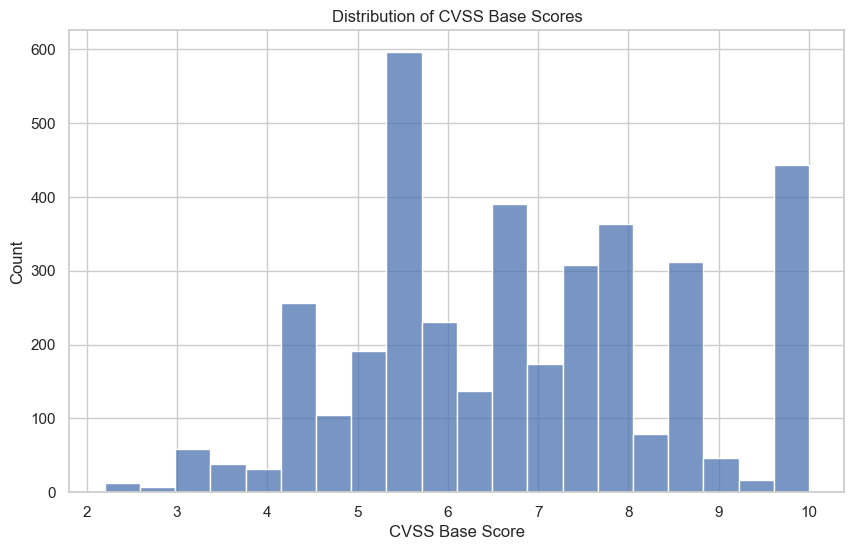

```python
# Analyze CVSS base score distribution
cvss_stats = df['cvss_baseScore'].describe()
print("CVSS Base Score Statistics:")
print(cvss_stats)

plt.figure(figsize=(10, 6))
sns.histplot(data=df, x='cvss_baseScore', bins=20)
plt.title('Distribution of CVSS Base Scores')
plt.xlabel('CVSS Base Score')
plt.ylabel('Count')
plt.show()
```

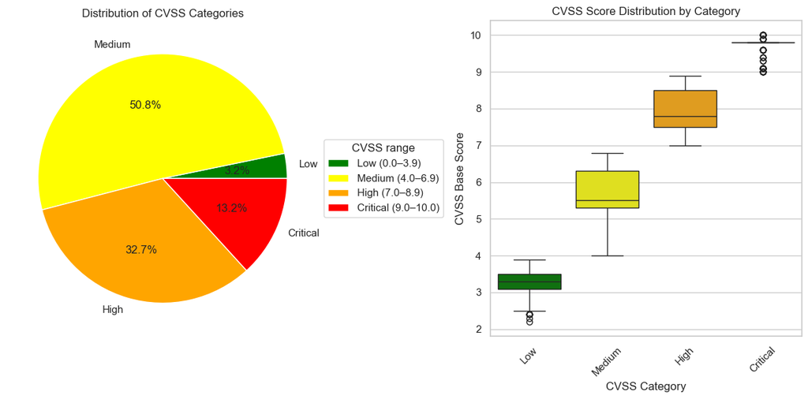

```
Summary Statistics by CVSS Category:
                count      mean       std  min  25%  50%  75%   max
cvss_category
Low             123.0  3.262602  0.389913  2.2  3.1  3.3  3.5   3.9
Medium         1928.0  5.584544  0.738903  4.0  5.3  5.5  6.3   6.8
High           1241.0  7.897421  0.583919  7.0  7.5  7.8  8.5   8.9
Critical        502.0  9.736653  0.212041  9.0  9.8  9.8  9.8  10.0
```

```python
def cvss_categorization(score):
    if pd.isna(score):
        return 'Unknown/NA'
    elif score < 4.0:
        return 'Low'
    elif 4.0 <= score < 7.0:
        return 'Medium'
    elif 7.0 <= score < 9.0:
        return 'High'
    else:
        return 'Critical'

df['cvss_category'] = df['cvss_baseScore'].apply(cvss_categorization)

# Calculate percentages of each CVSS category
total_vulns = len(df[df['cvss_baseScore'].notna()])
category_percentages = (df['cvss_category'].value_counts() / total_vulns * 100).round(2)

# Exclude the 'Unknown/NA' label and order categories by severity
desired_order = ['Low', 'Medium', 'High', 'Critical']
# Keep only the desired categories in that order and drop missing ones
category_percentages = category_percentages.reindex(desired_order).dropna()

# Create a pie chart
plt.figure(figsize=(12, 6))

# Subplot 1: Pie chart
plt.subplot(1, 2, 1)
palette = {'Low':'green', 'Medium':'yellow', 'High':'orange', 'Critical':'red'}
colors = [palette[c] for c in category_percentages.index]
plt.pie(category_percentages, labels=category_percentages.index, colors=colors, autopct='%1.1f%%')
# Add a legend describing the numeric CVSS ranges for each category

range_labels = {'Low':'0.0–3.9', 'Medium':'4.0–6.9', 'High':'7.0–8.9', 'Critical':'9.0–10.0'}
handles = [Patch(facecolor=palette[c], label=f"{c} ({range_labels[c]})") for c in category_percentages.index]
plt.legend(handles=handles, title='CVSS range', loc='center left', bbox_to_anchor=(1, 0.5))
plt.title('Distribution of CVSS Categories')

# Subplot 2: Box plot by category
plt.subplot(1, 2, 2)
#sns.boxplot(data=df, x='cvss_category', y='cvss_baseScore', order=desired_order,
          # palette=colors)
# Restrict boxplot to same categories and use same order/colors
sns.boxplot(data=df[df['cvss_category'].isin(category_percentages.index)],
            x='cvss_category', y='cvss_baseScore',
            order=category_percentages.index, palette=colors)
plt.xticks(rotation=45)
plt.title('CVSS Score Distribution by Category')
plt.xlabel('CVSS Category')
plt.ylabel('CVSS Base Score')

plt.tight_layout()
plt.show()

# Print summary statistics by category (exclude Unknown/NA and keep desired order)
summary = df[df['cvss_category'].isin(desired_order)].groupby('cvss_category')['cvss_baseScore'].describe().reindex(desired_order)
print("\nSummary Statistics by CVSS Category:")
print(summary)
```

These charts help us understand the severity labels better:

- **Most bugs are Medium or High**: The pie chart shows that **Medium** and **High** are the most common labels. **Critical** issues are fewer but still a big chunk of the pie. **Low** severity bugs are very rare.
- **Clear Groups**: The box plot shows that the scores fit neatly into their categories. You can see that "Critical" bugs are always at the very top (9.0 to 10.0).
- **Connecting to the previous chart**: The histogram showed us the scores were generally high. This breakdown confirms it: if you add up High and Critical, they make up a large part of the total. This means security teams have a lot of serious work to do, as they can't just ignore the "Medium" ones either.

## EPSS Distribution Analysis

Let's analyze the distribution of EPSS scores to understand the likelihood of vulnerabilities being exploited in the dataset.

```
EPSS Score Statistics:
count    4322.000000
mean        0.001477
std         0.017285
min         0.000020
25%         0.000240
50%         0.000320
75%         0.000470
max         0.810640
Name: epss, dtype: float64
```

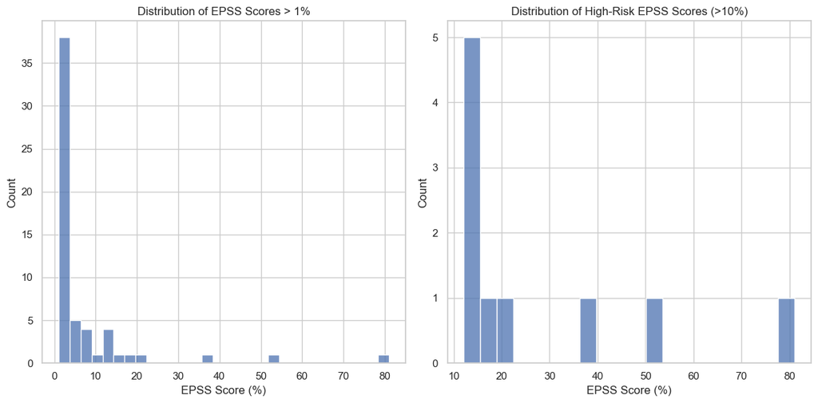

```
Risk Distribution Summary:
Total Vulnerabilities: 4322
High Risk (EPSS > 10%): 10 (0.23%)
Medium Risk (1% < EPSS ≤ 10%): 48 (1.11%)
Low Risk (EPSS ≤ 1%): 4264 (98.66%)
```

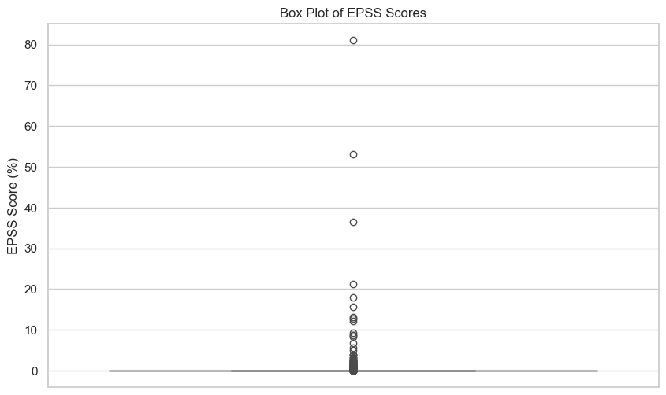

```python
# Analyze EPSS distribution
epss_stats = df['epss'].describe()
print("EPSS Score Statistics:")
print(epss_stats)

# Convert EPSS to percentage for better readability
df['epss_percentage'] = df['epss'] * 100

# Create more informative plots
plt.figure(figsize=(12, 6))
plt.subplot(1, 2, 1)
# Plot for EPSS > 1%
sns.histplot(data=df[df['epss_percentage'] > 1], x='epss_percentage', bins=30)
plt.title('Distribution of EPSS Scores > 1%')
plt.xlabel('EPSS Score (%)')
plt.ylabel('Count')

plt.subplot(1, 2, 2)
# Plot focusing on high-risk vulnerabilities
sns.histplot(data=df[df['epss_percentage'] > 10], x='epss_percentage', bins=20)
plt.title('Distribution of High-Risk EPSS Scores (>10%)')
plt.xlabel('EPSS Score (%)')
plt.ylabel('Count')
plt.tight_layout()
plt.show()

# Add summary statistics
total_vulns = len(df)
high_risk = len(df[df['epss_percentage'] > 10])
medium_risk = len(df[(df['epss_percentage'] <= 10) & (df['epss_percentage'] > 1)])
low_risk = len(df[df['epss_percentage'] <= 1])

print("\nRisk Distribution Summary:")
print(f"Total Vulnerabilities: {total_vulns}")
print(f"High Risk (EPSS > 10%): {high_risk} ({(high_risk/total_vulns)*100:.2f}%)")
print(f"Medium Risk (1% < EPSS ≤ 10%): {medium_risk} ({(medium_risk/total_vulns)*100:.2f}%)")
print(f"Low Risk (EPSS ≤ 1%): {low_risk} ({(low_risk/total_vulns)*100:.2f}%)")

# Show box plot for better visualization of outliers
plt.figure(figsize=(10, 6))
sns.boxplot(y=df['epss_percentage'])
plt.title('Box Plot of EPSS Scores')
plt.ylabel('EPSS Score (%)')
plt.show()
```

#### The Starting Point

- **The Big Picture**: We start with 4,322 vulnerabilities.
- **Most are Safe**: The statistics show that most of these are just "noise." About 4,264 of them have very low chance of being exploited (scores are about less than 1%).

#### The First Plot

- **Huge Drop**: When we look for scores above 1%, the number drops drastically. The left chart shows only about 50 to 60 items left.
- **What this means**: We filtered out about 98.6% of the list because they didn't even reach a 1% risk level.
- **What's left**: Even among these survivors, most (about 38) are still low risk, sitting between 1% and 5%.

#### The Second Plot

- **Zooming In**: The right chart looks at the high-risk items (over 10%). We are left with exactly 10 specific vulnerabilities.
- **The Details**:
  - 5 are between 10% and 15%.
  - 2 are between 15% and 25%.
  - 3 are very high outliers.

#### The Top Threat (Outlier)

- **The Highest Score**: The statistics show one vulnerability with a score of roughly 81%. The chart confirms this with a single bar at the far right.
- **Conclusion**: Out of 4,322 initial problems, there is one outlier that might represent a serious threat in the next 30 days

## CVSS vs EPSS Correlation

Let's create a scatter plot to visualize the relationship between CVSS base scores and EPSS scores to understand if there's any correlation between vulnerability severity and exploitation probability.

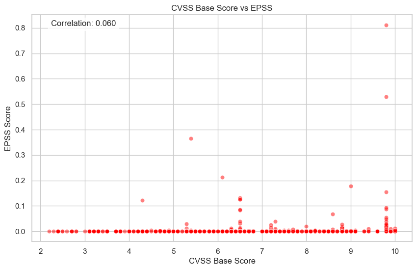

```python
filtered_data = df.dropna(subset=['cvss_baseScore', 'epss'])

# Create scatter plot of CVSS vs EPSS
plt.figure(figsize=(10, 6))
sns.scatterplot(data=filtered_data,
                x='cvss_baseScore',
                y='epss',
                alpha=0.5,
                color='red')
plt.title('CVSS Base Score vs EPSS')
plt.xlabel('CVSS Base Score')
plt.ylabel('EPSS Score')

# Calculate correlation
correlation = filtered_data['cvss_baseScore'].corr(filtered_data['epss'])
plt.text(0.05, 0.95, f'Correlation: {correlation:.3f}',
         transform=plt.gca().transAxes,
         bbox=dict(facecolor='white', alpha=0.8))
plt.show()
```

#### CVSS vs EPSS Analysis

- **Near-Zero Correlation**: The scatter plot shows almost no statistical connection between CVSS and EPSS, with a correlation of just 0.060.
- **Flat Line**: Visually, there is a dense horizontal line of red dots along the very bottom of the chart (EPSS ≈ 0). This line stretches across every severity level, from low (2.0) all the way to critical (10.0).
- **Severity ≠ Likelihood**: This pattern confirms that a "critical" CVSS score does not automatically imply a high chance of exploitation.
- **Outliers**: While the few most dangerous outliers in the top right do have high severity scores, the vast majority of high-severity vulnerabilities in the dataset have almost zero probability of being weaponized.
- **Important aspect**: The plot suggests that severity alone does not determine the likelihood of exploitation, hence there might be other factors such as target popularity and attack complexity that play a crucial role in the prediction.

## Most Frequent Vendors

In the following section we try to extract the vendor identities from "vulnerable_cpes" and visualize the top 20 most prevalent vendors in the dataset.

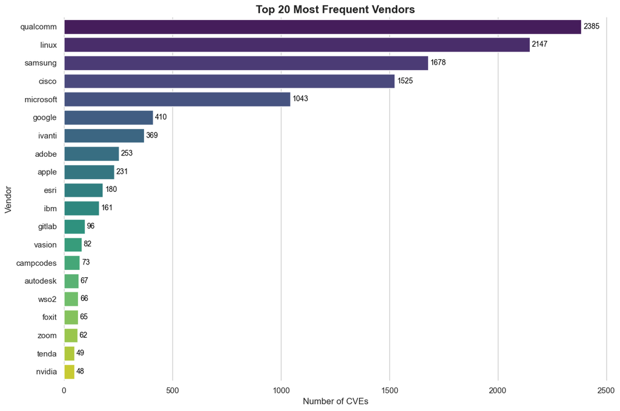

```python
vendors = []
# Assuming df is already defined in your environment
for cpes in df['vulnerable_cpes'].dropna():
    for cpe in cpes:
        parts = cpe.split(':')
        if len(parts) >= 4:     # Extract vendor from CPE string (4th field after splitting by ':')
            vendor = parts[3]
            vendors.append(vendor)

vendor_counts = Counter(vendors).most_common(20)
vendor_df = pd.DataFrame(vendor_counts, columns=['Vendor', 'Count'])

# Set a clean background style
sns.set_style("whitegrid")

plt.figure(figsize=(12, 8))



ax = sns.barplot(
    data=vendor_df,
    x='Count',
    y='Vendor',
    palette='viridis',
    hue='Vendor',
    legend=False
)

# Add exact numbers to the end of the bars
for container in ax.containers:
    ax.bar_label(container, padding=3, fontsize=10, color='black')

plt.xlabel('Number of CVEs', fontsize=12)
plt.ylabel('Vendor', fontsize=12)
plt.title('Top 20 Most Frequent Vendors', fontsize=15, fontweight='bold')

# Remove the box border for a cleaner look
sns.despine(left=True, bottom=True)

plt.tight_layout()
plt.show()
```

## Most Frequent CWEs

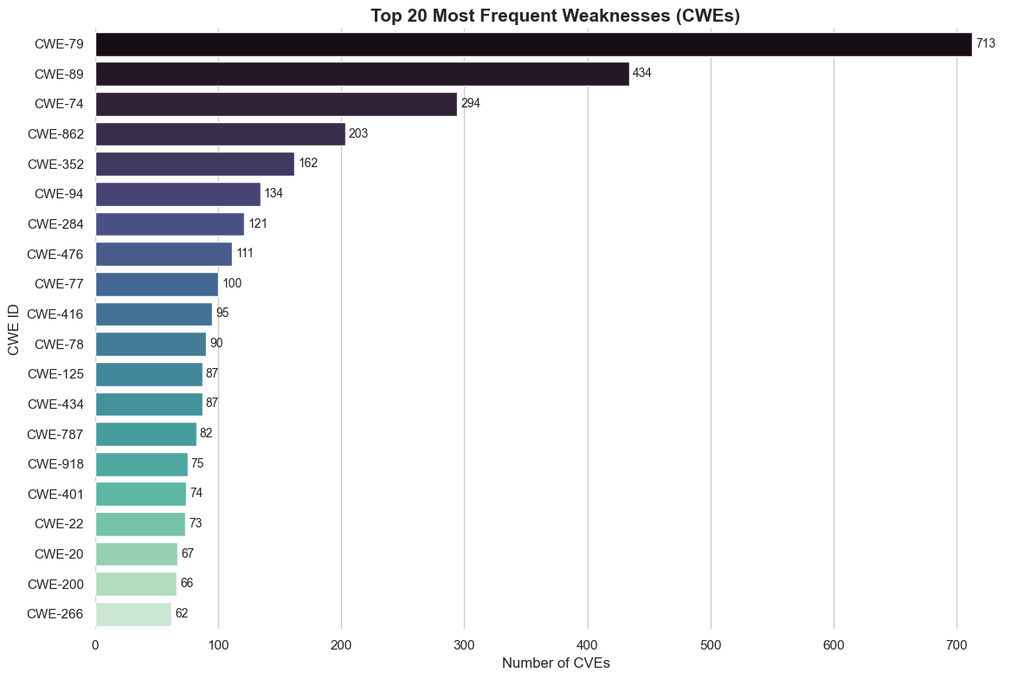

```python
cwe_list = []

for cwes in df['cwe_list'].dropna():
    for cwe in cwes:
        cwe_list.append(cwe)

# Count and get top 20
cwe_counts = Counter(cwe_list).most_common(20)
cwe_df = pd.DataFrame(cwe_counts, columns=['CWE', 'Count'])


sns.set_style("whitegrid")
plt.figure(figsize=(12, 8))


ax = sns.barplot(
    data=cwe_df,
    x='Count',
    y='CWE',
    palette='mako',
    hue='CWE',
    legend=False
)

# Add exact count labels to the end of the bars
for container in ax.containers:
    ax.bar_label(container, padding=3, fontsize=10)

plt.xlabel('Number of CVEs', fontsize=12)
plt.ylabel('CWE ID', fontsize=12)
plt.title('Top 20 Most Frequent Weaknesses (CWEs)', fontsize=15, fontweight='bold')

# Clean up the borders
sns.despine(left=True, bottom=True)

plt.tight_layout()
plt.show()
```

#### Top CWEs Analysis

Analyzing the breakdown of CWEs enables defenders to prioritize their efforts against the most widespread vulnerability types.

## Additional analysis

The idea is to explore which features of the dataset might help me predict changes in the EPSS score, from low to high.

EPSS is influenced by both **technical severity** (CVSS) and **threat context**, for example exploit availability, attention from researchers, public references and many more.

### Most relevant predictors:

- Reference-related features:
  - **num_references**

    A CVE with many references (especially GitHub or exploit DBs) is more likely to attract attacker interest.
  - **cve.references**

    Extracting reference sources -> Certain sources such as GitHub, vuldb, exploit-db might be strong signals of active discussion.
- Dangerous CWE types
  - **cwe_list**

    Certain CWEs are more prone to exploitation. As our previous analysis showed, specific vulnerability classes (like XSS or SQL Injection) appear far more frequently than others. We also know that these two CWEs are historically the most exploited weakness types. These structural weaknesses are often easier to automate and exploit at scale, making them strong predictors of future weaponization.
- Product Vendors
  - Extracted from **vulnerable_cpes**

    Major vendors like Microsoft and Cisco are prime targets for hackers because their widespread use means a single exploit can hit thousands of victims, making their vulnerabilities far more likely to be attacked than those in targeted products.
- Publication Timing
  - **cve.published** & **cve.lastModified**

    Newly published CVEs with rapid modification may indicate some growing awarness
- Percentile
  - **percentile**

    Percentile encodes relative exploit likelihood in the global distribution. A CVE with low EPSS but a percentile close to 0.1 might already grow up.
- Base Severity & Impact
  - **cvss_baseSeverity** & **cvss_confidentialityImpact** & **cvss_integrityImpact** & **cvss_availabilityImpact**

    These aspects reflect to potential impact but not the likelihood of exploitation. However, when combined with network attack vector and low attack complexity, they may indicate easier exploitation paths.

### Less useful predictors:

- **cvss_baseScore** & **cvss_version**

  CVSS measures impact, not exploit likelihood. High CVSS **not** imply future EPSS growth

## EPSS Filtering

```python
# Filtering out low EPSS scores - less than 0.1 (1%)
#low_epss_df = df.loc[df['epss'] < 0.1]
low_epss_df = df[df['epss'] < 0.1].copy()
filtered_df = low_epss_df["epss"]

#print(low_epss_df)
print(filtered_df)
print(f"Low EPSS CVEs (<0.1): {len(filtered_df)}")
```

```
0       0.00030
1       0.00242
2       0.00026
3       0.00028
4       0.00028
         ...
4317    0.00018
4318    0.00027
4319    0.00150
4320    0.00028
4321    0.00017
Name: epss, Length: 4312, dtype: float64
Low EPSS CVEs (<0.1): 4312
```

## Feature Engineering

I am about to create additional and more meaninfgul feature to analyze potential exploitability trends.

- **has_github_ref:**
  - Set to TRUE if references contain a GitHub link -> PoC code indicator
- **is_dangerous_cwe:**
  - Storing the information whether a CVE has historically dangerous CWE
- **is_popular_vendor:**
  - Storing info whether a CVE is encountered in a popular vendor's product.
- **days_to_modify:**
  - Number of days between publication and last modification

```python
# CONTAINS_GITHUB_REF
def contains_github(refs):
    return 'github' in str(refs).lower()

low_epss_df.loc[:, 'has_github_ref'] = low_epss_df['cve.references'].apply(contains_github)



# DANGEROUS_CWES
dangerous_cwes = [
    'CWE-78',   # OS Command Injection
    'CWE-79',   # Cross-site Scripting (XSS)
    'CWE-89',   # SQL Injection
    'CWE-22',   # Path Traversal
    'CWE-434',  # Unrestricted Upload
    'CWE-94',   # Code Injection
    'CWE-77',   # Command Injection
    'CWE-502',  # Deserialization
    'CWE-20',   # Improper Input Validation
    'CWE-119',  # Buffer Overflow
    'CWE-787',  # Out-of-bounds Write
    'CWE-121',  # Stack-based Buffer Overflow
    'CWE-74',   # Injection
] # Compare the most dangerous CWEs with the most frequent CWEs from previous analysis


def has_dangerous_cwe(cwe_list):
    if not cwe_list:
        return False
    for cwe in cwe_list:
        if cwe in dangerous_cwes:
            return True
    return False

low_epss_df.loc[:, 'has_dangerous_cwe'] = low_epss_df['cwe_list'].apply(has_dangerous_cwe)






# POPULAR_VENDORS
# First we need to extract the vendor from the CPE strings
def extract_vendor(cpes):
    if not cpes or not isinstance(cpes, list):
        return 'unknown'

    parts = cpes[0].split(':')
    if len(parts) >= 4:
        return parts[3]
    return 'unknown'

low_epss_df.loc[:, 'vendor'] = low_epss_df['vulnerable_cpes'].apply(extract_vendor)

# List of popular vendors to focus on -> Some correlations with the most frequent vendors!
popular_vendors = [
    'dell', 'cisco', 'microsoft', 'qualcomm',
    'google', 'apple', 'adobe', 'ivanti',
    'ibm', 'gitlab', 'samsung', 'hp', 'linux'
]

def is_popular_vendor(vendor):
    # 1. Check if it's actually a string first
    if not isinstance(vendor, str):
        return False

    # 2. Check the specific conditions
    if vendor == 'unknown':
        return False

    return vendor.lower() in popular_vendors

low_epss_df.loc[:, 'is_popular_vendor'] = low_epss_df['vendor'].apply(is_popular_vendor)




# DAYS_TO_MODIFY
low_epss_df['days_to_modify'] = (
    pd.to_datetime(low_epss_df['cve.lastModified']) -
    pd.to_datetime(low_epss_df['cve.published'])
).dt.days.fillna(0)


low_epss_df[['cve.id', 'epss', 'percentile', 'num_references', 'has_github_ref',
'has_dangerous_cwe', 'is_popular_vendor', 'days_to_modify']].head(20)

#low_epss_df[['days_to_modify']].sort_values('days_to_modify', ascending=False).head(20)

#print(f"OK CVEs with dangerous CWEs: {low_epss_df['has_dangerous_cwe'].sum()}/{len(low_epss_df)}")
#print(f"OK CVEs from popular vendors: {low_epss_df['is_popular_vendor'].sum()}/{len(low_epss_df)}")
```

|  | cve.id | epss | percentile | num_references | has_github_ref | has_dangerous_cwe | is_popular_vendor | days_to_modify |
| --- | --- | --- | --- | --- | --- | --- | --- | --- |
| 0 | CVE-2025-9751 | 0.00030 | 0.07395 | 6 | True | True | False | 7 |
| 1 | CVE-2025-9752 | 0.00242 | 0.47575 | 6 | True | True | False | 3 |
| 2 | CVE-2025-9753 | 0.00026 | 0.05727 | 5 | True | True | False | 3 |
| 3 | CVE-2025-9754 | 0.00028 | 0.06386 | 5 | True | True | False | 3 |
| 4 | CVE-2025-9755 | 0.00028 | 0.06393 | 5 | True | True | False | 4 |
| 5 | CVE-2025-9756 | 0.00028 | 0.06611 | 6 | True | True | False | 7 |
| 6 | CVE-2025-9567 | 0.00047 | 0.14213 | 2 | False | True | False | 24 |
| 7 | CVE-2025-9568 | 0.00047 | 0.14213 | 2 | False | True | False | 24 |
| 8 | CVE-2025-9569 | 0.00047 | 0.14213 | 2 | False | True | False | 24 |
| 9 | CVE-2025-9757 | 0.00030 | 0.07395 | 6 | True | True | False | 7 |
| 10 | CVE-2025-7405 | 0.00219 | 0.44706 | 3 | False | False | False | 1 |
| 11 | CVE-2025-7731 | 0.00016 | 0.02464 | 3 | False | False | False | 1 |
| 12 | CVE-2025-9570 | 0.00062 | 0.19733 | 2 | False | False | False | 24 |
| 13 | CVE-2025-9758 | 0.00028 | 0.06611 | 7 | True | True | False | 10 |
| 14 | CVE-2025-9759 | 0.00030 | 0.07395 | 5 | True | True | False | 7 |
| 15 | CVE-2025-9760 | 0.00048 | 0.14565 | 8 | True | False | False | 25 |
| 16 | CVE-2025-9761 | 0.00030 | 0.07395 | 6 | True | True | False | 7 |
| 17 | CVE-2025-9763 | 0.00030 | 0.07395 | 6 | True | True | False | 7 |
| 18 | CVE-2025-20703 | 0.00278 | 0.51085 | 1 | False | False | False | 2 |
| 19 | CVE-2025-20704 | 0.00198 | 0.42262 | 1 | False | True | False | 2 |

## Candidate selection

```python
"""candidates = low_epss_df[
    (low_epss_df['percentile'] > 0.05) &
    (low_epss_df['has_github_ref']) &
    (low_epss_df['num_references'] > 5) &
    (low_epss_df['cvss_attackVector'] == 'NETWORK') &
    (low_epss_df['cvss_attackComplexity'] == 'LOW')
].sort_values('percentile', ascending=False).head(10)"""

def calculate_growth_potential(row):
    score = 0


    if row['has_github_ref']:
        score += 3


    if row['is_popular_vendor']:
        score += 2


    if row['has_dangerous_cwe']:
        score += 2


    if row['cvss_attackVector'] == 'NETWORK':
        score += 1.5


    if row['cvss_attackComplexity'] == 'LOW':
        score += 1

    if row['days_to_modify'] > 60:
        score += 0.5

    if row['num_references'] > 0:
        # Cap the bonus at 1.0
        score += min(2.0, row['num_references'] / 5.0)  # 1 point for every 5 references

    return score

# Calculate the score
low_epss_df['growth_potential_score'] = low_epss_df.apply(calculate_growth_potential, axis=1)

# Select Top 10 Candidates
candidates = low_epss_df[low_epss_df['percentile'] > 0.05].sort_values(
    ['growth_potential_score', 'epss'],
    ascending=[False, False]
).head(10)

# 3. Display the results to verify why they were picked
cols_to_show = [
    'cve.id', 'epss', 'growth_potential_score',
    'has_github_ref', 'is_popular_vendor',
    'has_dangerous_cwe', 'num_references', 'days_to_modify', 'cvss_attackVector'
]
print("\nTop 10 CVEs Likely to Increase in EPSS:")
#print(candidates[cols_to_show].to_string(index=False))



#print(candidates[['cve.id', 'epss', 'percentile', 'num_references',
                  #'cvss_attackVector', 'cvss_attackComplexity',
                  #'has_github_ref', 'days_to_modify']])

print(candidates["cve.id"].head(10))
```

```
Top 10 CVEs Likely to Increase in EPSS:
69       CVE-2025-9789
3032    CVE-2025-10769
79       CVE-2025-9796
83       CVE-2025-9801
82       CVE-2025-9800
1002    CVE-2025-10083
3044    CVE-2025-10779
3985    CVE-2025-11031
76       CVE-2025-9794
388      CVE-2025-9923
Name: cve.id, dtype: object
```

```python
nickname = 'TheExploitables' # TODO: put your nickname here


# TODO: put your selected IDs here
selected = ['CVE-2025-9789',
            'CVE-2025-10769',
            'CVE-2025-9796',
            'CVE-2025-9801',
            'CVE-2025-9800',
            'CVE-2025-10083',
            'CVE-2025-10779',
            'CVE-2025-11031',
            'CVE-2025-9794',
            'CVE-2025-9923',
           ]

df[df['cve.id'].isin(selected)].to_csv(os.path.join(data_path, f'{nickname}.csv'))
```

## EPSS Trend Analysis

> To replicate this analysis and start the visualization application, run the provided Python script in your terminal using the following command:

> ```
> streamlit run epss_tracker.py
> ```

The application collected daily probability scores from **October 1, 2025** to present. The objective was to determine if risk scores remained stable or exhibited "velocity" (rapid growth).

[figure not shown]

*Figure 1: Analysis of EPSS scores over a 2-month period.*

The visual data confirms that risk is not static. While the majority of vulnerabilities remained flat, specific outliers demonstrated clear upward trends:

- **🔴 CVE-2025-11031 (Red Line):** This had the biggest change. It started low (**0.05%**) and tripled at **0.17%**.
- **🟣 CVE-2025-9789 (Purple Line):** Doubled in score between October and November before staying flat again.

### Takeaways

**1. The "Step Function" of Risk**

The trend lines do not rise smoothly; they jump in discrete **steps**. This suggests the score reacts to specific trigger events, such as a hacker attempting an exploit or the publication of new threat intelligence online.

**2. Relative Growth vs. Absolute Score**

Monitoring the *rate of change* (trend) is just as critical as analyzing the static score itself.